# DV_TProject1

Name: Ke Chen, Abhinav Bannerjee

UT EID: kc35827, ab45393

### General Steps

1. Find the .csv data
2. create the repository in Github. 3 create project with four directories.
3. Using R_etl.r to reformat our datas and import data into ORACL SQL.
4. Query datas from server, and create Tableau workbook.
5. make three different grpah by using graph.
6. make explanation on each plot.
7. Knit R, combine all file into a html file.

### R_ETL.R file operation

The R_ETL file generates a code for us to create a table in Oracle SQL.

```
## CREATE TABLE 2016_FE_Guide_for_DOE (
## -- Change table_name to the table name you want.
##  Mfr_Name varchar2(4000),
##  Division varchar2(4000),
##  Carline varchar2(4000),
##  Verify_Mfr_Cd varchar2(4000),
##  Transmission varchar2(4000),
##  Guzzler_ varchar2(4000),
##  Air_Aspiration_Method_Desc varchar2(4000),
##  Trans_Desc varchar2(4000),
##  Lockup_Torque_Converter varchar2(4000),
##  Trans_Creeper_Gear varchar2(4000),
##  Drive_Desc varchar2(4000),
##  Fuel_Usage_Desc varchar2(4000),
##  Carline_Class_Desc varchar2(4000),
##  Release_Date varchar2(4000),
##  Var_Valve_Timing_ varchar2(4000),
##  Var_Valve_Lift_ varchar2(4000),
##  Energy_Storage_Device_Desc varchar2(4000),
##  Battery_Type_Desc varchar2(4000),
##  Batt_Charger_Type_Desc varchar2(4000),
##  Regen_Braking_Type_Desc varchar2(4000),
##  Regen_Braking_Wheels_Source varchar2(4000),
##  Driver_Cntrl_Regen_Braking_ varchar2(4000),
##  Motor_Gen_Type_Desc varchar2(4000),
##  Fuel_Metering_Sys_Desc varchar2(4000),
##  Fuel_Cell_Vehicle varchar2(4000),
##  Off_Board_Charge_Capable varchar2(4000),
##  Camless_Valvetrain varchar2(4000),
##  Oil_Viscosity varchar2(4000),
##  Stop_Start_Engine varchar2(4000),
##  Model_Year number(38,4),
##  Eng_Displ number(38,4),
##  Numbers_of_Cyl number(38,4),
##  City_FE_Guide number(38,4),
##  Hwy_FE_Guide number(38,4),
##  Comb_FE_Guide number(38,4),
##  Numbers_of_Gear number(38,4),
##  Max_Ethanol_Gasoline number(38,4),
##  Annual_Fuel_Cost number(38,4),
##  Calculated_Annual_Fuel_Cost number(38,4),
##  EPA_FE_Label_Dataset_ID number(38,4),
##  Numbers_of_Batteries number(38,4),
##  Total_Voltage_for_Battery number(38,4),
##  Batt_Energy_Cpacity_Amp_hrs number(38,4),
##  Batt_Specific_Energy_Watt number(38,4),
##  Numbers_of_Drive_Motor_Gen number(38,4),
##  Rated_Motor_Gen_Power_kW number(38,4),
##  Calculated_Gas_Guzzler_MPG number(38,4),
##  FE_Rating_1_10 number(38,4),
##  five_years_savings number(38,4),
##  five_years_spend number(38,4),
##  City_CO2_Rounded_Adjusted number(38,4),
##  Hwy_CO2_Rounded_Adjusted number(38,4),
##  Comb_CO2_Rounded_Adjusted number(38,4)
##  );
```

### visualization

##### Scatter Plot

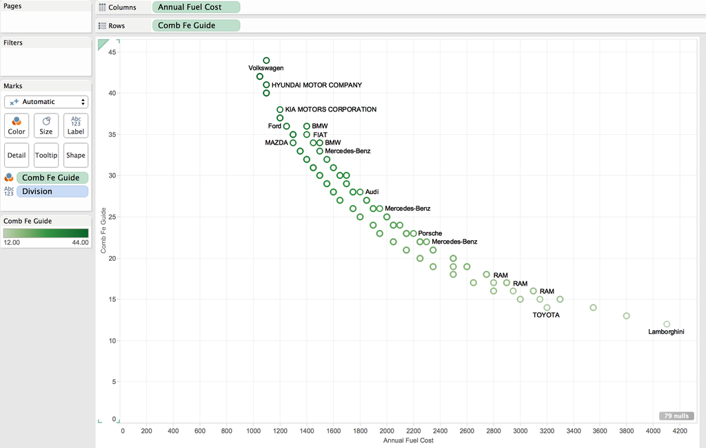

This visualization shows the most efficient vehicles based on mileage and annual fuel costs incurred on the driver. Naturally, economy class cars tend to be more efficient and cost effective(cost less).

##### Crosstab

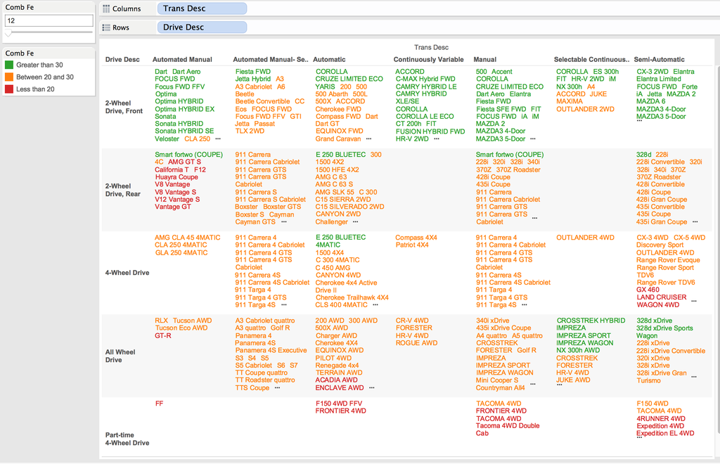

This visualization displays the most efficient cars and segments car models based on transmission and drive type. Front 2-wheel driven cars seem to be most efficient, regardless transmission type.

##### Bar Chart

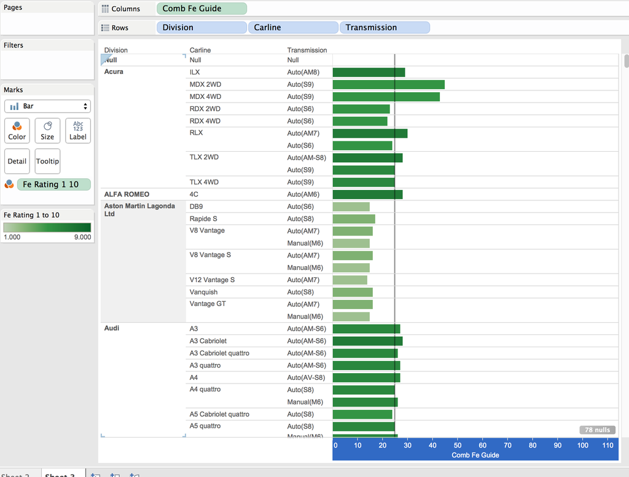

This visualization breaks down cars by manufacturer and make. It then proceeds to aggregate fuel efficiency ratings for each car (and distinguishes between transmission types). Sports vehicles are clearly below the median mileage here. The reference line stands for the median Combinantion Fuel. And we can see clearly which carline are below the median, and which are above the median.